# 7e56ce8d-276a-448e-aba0-3d0e56b5b711

Hola 😀

Soy **Hesus Garcia** como "Jesús" pero con H. Sé que puede ser confuso al principio, pero una vez que lo recuerdes, ¡nunca lo olvidarás! 🌝 . Como revisor de código de Triple-Ten, estoy emocionado de examinar tus proyectos y ayudarte a mejorar tus habilidades en programación. si has cometido algún error, no te preocupes, pues ¡estoy aquí para ayudarte a corregirlo y hacer que tu código brille! 🌟. Si encuentro algún detalle en tu código, te lo señalaré para que lo corrijas, ya que mi objetivo es ayudarte a prepararte para un ambiente de trabajo real, donde el líder de tu equipo actuaría de la misma manera. Si no puedes solucionar el problema, te proporcionaré más información en la próxima oportunidad. Cuando encuentres un comentario, **por favor, no los muevas, no los modifiques ni los borres**.

Revisaré cuidadosamente todas las implementaciones que has realizado para cumplir con los requisitos y te proporcionaré mis comentarios de la siguiente manera:

**Comentario del revisor** Si todo está perfecto.

**Comentario del revisor** Si tu código está bien pero se puede mejorar o hay algún detalle que le hace falta.

**Comentario del revisor** Si de pronto hace falta algo o existe algún problema con tu código o conclusiones.

Puedes responderme de esta forma:

**Respuesta del estudiante**

**¡Empecemos!** 🚀

## PROYECTO

1. Preprocesamiento de Datos
- Técnicas de Filtrado: Aplicar filtrado univariado para identificar las características relevantes desde un punto de vista estadístico.
- Normalización y Escalado: Preprocesar los datos numéricos, incluyendo normalización y escalado, y realizar la codificación de variables categóricas utilizando One-Hot Encoding o Embedding, según corresponda.
2. Selección de Características
- Aplicar métodos avanzados como Boruta para identificar las características más relevantes.
- Utilizar SHAP para interpretar y explicar las predicciones de los modelos, especialmente cuando se utilicen modelos complejos como árboles de decisión o redes neuronales.
3. Entrenamiento de Modelos
- Entrenar varios modelos de clasificación y regresión (dependiendo del tipo de problema), como regresión logística, árboles de decisión, redes neuronales profundas, y modelos basados en ensambles (Random Forest, XGBoost).
- Evaluar diferentes combinaciones de hiperparámetros utilizando técnicas como la búsqueda en cuadrícula o búsqueda aleatoria.
4. Evaluación de Modelos
- Utilizar precisión, recall, F1-Score y ROC-AUC para evaluar el rendimiento de los modelos de clasificación.
- Para tareas de regresión, evaluar con RMSE y MAE para medir la precisión de las predicciones numéricas.
5. Optimización y Mejora Continua
- Interpretar los resultados con técnicas como SHAP para realizar ajustes en el modelo.
- Explorar mejoras a través de la ingeniería de características y el ajuste de hiperparámetros.

El plan ha sido mejorado para incluir técnicas avanzadas de selección de características (como Boruta y SHAP) y para garantizar que se utilicen las métricas adecuadas para problemas de clasificación desbalanceada, como F1-score y ROC-AUC. Además, el preprocesamiento de datos será más exhaustivo, aplicando técnicas de filtrado y embedding, lo cual mejora la calidad de los datos de entrada. Este enfoque optimizado asegurará que el modelo alcance el mejor rendimiento posible y sea interpretable.

**Comentario del revisor** Adelante Giovani, por favor procede a realizar tu código en este notebook.

Hola, muchas gracias por los comentarios del proyecto, tengo una consulta en el momento en el que empiece el codigo no tengo la dirección del archivo. este deveria pedirlo o usar una dirección ficticia de este mismo?.

```python
import pandas as pd
import matplotlib.pyplot as plt
import seaborn as sns
```

```python
import os

folder_path = '/datasets/final_provider'
files = os.listdir(folder_path)
files
```

```
['contract.csv', 'phone.csv', 'personal.csv', 'internet.csv']
```

```python
file_names = ['contract.csv', 'phone.csv', 'personal.csv', 'internet.csv']

dataframes = {}

for file in file_names:
    file_path = f"{folder_path}/{file}"
    dataframes[file] = pd.read_csv(file_path)
```

```python
dataframes['contract.csv']
```

|  | customerID | BeginDate | EndDate | Type | PaperlessBilling | PaymentMethod | MonthlyCharges | TotalCharges |
| --- | --- | --- | --- | --- | --- | --- | --- | --- |
| 0 | 7590-VHVEG | 2020-01-01 | No | Month-to-month | Yes | Electronic check | 29.85 | 29.85 |
| 1 | 5575-GNVDE | 2017-04-01 | No | One year | No | Mailed check | 56.95 | 1889.5 |
| 2 | 3668-QPYBK | 2019-10-01 | 2019-12-01 00:00:00 | Month-to-month | Yes | Mailed check | 53.85 | 108.15 |
| 3 | 7795-CFOCW | 2016-05-01 | No | One year | No | Bank transfer (automatic) | 42.30 | 1840.75 |
| 4 | 9237-HQITU | 2019-09-01 | 2019-11-01 00:00:00 | Month-to-month | Yes | Electronic check | 70.70 | 151.65 |
| ... | ... | ... | ... | ... | ... | ... | ... | ... |
| 7038 | 6840-RESVB | 2018-02-01 | No | One year | Yes | Mailed check | 84.80 | 1990.5 |
| 7039 | 2234-XADUH | 2014-02-01 | No | One year | Yes | Credit card (automatic) | 103.20 | 7362.9 |
| 7040 | 4801-JZAZL | 2019-03-01 | No | Month-to-month | Yes | Electronic check | 29.60 | 346.45 |
| 7041 | 8361-LTMKD | 2019-07-01 | 2019-11-01 00:00:00 | Month-to-month | Yes | Mailed check | 74.40 | 306.6 |
| 7042 | 3186-AJIEK | 2014-08-01 | No | Two year | Yes | Bank transfer (automatic) | 105.65 | 6844.5 |

7043 rows × 8 columns

```python
contract_df = dataframes['contract.csv']
print(contract_df.head())
print(contract_df.info())
```

```
   customerID   BeginDate              EndDate            Type  \
0  7590-VHVEG  2020-01-01                   No  Month-to-month
1  5575-GNVDE  2017-04-01                   No        One year
2  3668-QPYBK  2019-10-01  2019-12-01 00:00:00  Month-to-month
3  7795-CFOCW  2016-05-01                   No        One year
4  9237-HQITU  2019-09-01  2019-11-01 00:00:00  Month-to-month

  PaperlessBilling              PaymentMethod  MonthlyCharges TotalCharges
0              Yes           Electronic check           29.85        29.85
1               No               Mailed check           56.95       1889.5
2              Yes               Mailed check           53.85       108.15
3               No  Bank transfer (automatic)           42.30      1840.75
4              Yes           Electronic check           70.70       151.65
<class 'pandas.core.frame.DataFrame'>
RangeIndex: 7043 entries, 0 to 7042
Data columns (total 8 columns):
 #   Column            Non-Null Count  Dtype
---  ------            --------------  -----
 0   customerID        7043 non-null   object
 1   BeginDate         7043 non-null   object
 2   EndDate           7043 non-null   object
 3   Type              7043 non-null   object
 4   PaperlessBilling  7043 non-null   object
 5   PaymentMethod     7043 non-null   object
 6   MonthlyCharges    7043 non-null   float64
 7   TotalCharges      7043 non-null   object
dtypes: float64(1), object(7)
memory usage: 440.3+ KB
None
```

```python
contract_df.describe()

print(contract_df.isnull().sum())


print(contract_df.dtypes)
```

```
customerID          0
BeginDate           0
EndDate             0
Type                0
PaperlessBilling    0
PaymentMethod       0
MonthlyCharges      0
TotalCharges        0
dtype: int64
customerID           object
BeginDate            object
EndDate              object
Type                 object
PaperlessBilling     object
PaymentMethod        object
MonthlyCharges      float64
TotalCharges         object
dtype: object
```

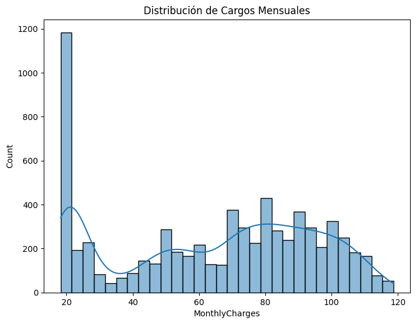

[figure not shown]

```python
# Distribución de los Cargos Mensuales (MonthlyCharges)
plt.figure(figsize=(8, 6))
sns.histplot(contract_df['MonthlyCharges'], kde=True, bins=30)
plt.title('Distribución de Cargos Mensuales')
plt.xlabel('MonthlyCharges')
plt.show()

# Distribución de los Cargos Totales (TotalCharges)
plt.figure(figsize=(8, 6))
sns.histplot(contract_df['TotalCharges'], kde=True, bins=30)
plt.title('Distribución de Cargos Totales')
plt.xlabel('TotalCharges')
plt.show()
```

```
count    1869.000000
mean      547.352060
std       594.389607
min        30.000000
25%        61.000000
50%       304.000000
75%       883.000000
max      2191.000000
Name: ContractDuration, dtype: float64
```

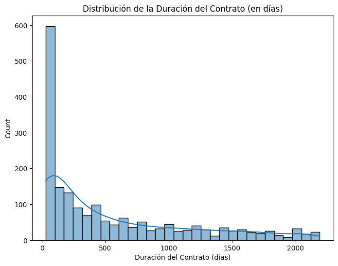

```python
# Convertir las fechas 'BeginDate' y 'EndDate' a formato datetime
contract_df['BeginDate'] = pd.to_datetime(contract_df['BeginDate'])
contract_df['EndDate'] = pd.to_datetime(contract_df['EndDate'], errors='coerce')

# Calcular la duración del contrato en días
contract_df['ContractDuration'] = (contract_df['EndDate'] - contract_df['BeginDate']).dt.days

# Descripción de la duración del contrato
print(contract_df['ContractDuration'].describe())

# Distribución de la duración del contrato
plt.figure(figsize=(8, 6))
sns.histplot(contract_df['ContractDuration'], kde=True, bins=30)
plt.title('Distribución de la Duración del Contrato (en días)')
plt.xlabel('Duración del Contrato (días)')
plt.show()
```

Preguntas Aclaratorias ¿Cómo debemos tratar los contratos que no tienen fecha de finalización?:

¿Se considera que estos clientes están activos, o debemos hacer alguna transformación adicional sobre ellos? Para el campo TotalCharges, en los casos donde los datos sean nulos o incorrectos, ¿deberíamos imputarlos (por ejemplo, con la mediana), o se espera que los eliminemos del análisis?.

¿Existen características específicas que el equipo considere cruciales para el análisis y modelado (por ejemplo, PaymentMethod, Type, etc.)?

¿Cuál es el objetivo principal del modelado?:

¿Queremos predecir la duración del contrato, la probabilidad de cancelación, o existe otro objetivo específico?